# nasal and bronchial DEG clustering and comparison

```r
getwd()
```

```
## [1] "C:/Users/kimyo/Dropbox/Research/asthma_bal"
```

Previously, DEG was performed and several models showed signficant DEG

design_list<-c(“Bronchial . BAL Eos%, all (continuous) + batch(12346)”, “Bronchial . BAL ANC, >0 (continuous) + batch(12346)”, “Bronchial . BAL Eos% > 3% vs <3% + batch(12346)”, “Bronchial . Blood AEC > 300 vs <300 + batch(12346)”, “Nasal . Blood AEC, >0 (continuous) + batch(1234)”, “Bronchial . BAL Eos% > 1% vs <1% + batch(12346)”, “Bronchial . BAL AEC >1.15 vs <1.15 + batch(12346)”)

K means clustering was performed. Some interesting clusters were identified.

these are the files.

```r
d1<-"./reports/local_only/deg_bronch~bal_cell(continuous)+batch12346/gene_list_sig_results/deg_bronch_continuous_allcell+batch12346_res_sig_2_~ BAL_eos_p_log + Batch_2024-08-02_.csv"

file.exists(d1)
```

```
## [1] TRUE
```

```r
d2<-"./reports/local_only/deg_bronch~bal_cell(continuous)+batch12346/gene_list_sig_results/deg_bronch_continuous_allcell+batch12346_res_sig_5_~ BAL_wbc_log + Batch_2024-08-02_.csv"

d3<-"./reports/local_only/deg_bronch~bal_cell(continuous)+batch12346/gene_list_sig_results/deg_bronch_continuous_poscell+batch12346_res_sig_3_~ BAL_neut_ct_log + Batch_2024-05-29_.csv"

d4<-"./reports/local_only/deg_bronch~bal_cell(dichot)+batch12346/deg_bronch_dichot_res_sig_5_~ bal_Eos_p_more_3 + Batch_2024-05-29_.csv"

d5<-"./reports/local_only/deg_bronch~bal_cell(dichot)+batch12346/deg_bronch_dichot_res_sig_14_~ bld_AEC_more_300 + Batch_2024-05-29_.csv"

d6<-"./reports/local_only/deg_nasal-bronch~bal-blood_cell(continuous)+batch/deg_gene_list/deg_Nasal_poscells_~ blood_eos_log + Batch_res_6_2024-01-09_.csv"

d7<-"./reports/local_only/deg_bronch~bal_cell(dichot)+batch12346/deg_bronch_dichot_res_sig_4_~ bal_Eos_p_more_1 + Batch_2024-05-29_.csv"

d8<-"./reports/local_only/deg_bronch~bal_cell(dichot)+batch12346/deg_bronch_dichot_res_sig_2_~ bal_AEC_more_1.15 + Batch_2024-05-29_.csv"

sapply(c(d1,d2,d3,d4,d5,d6,d7,d8),file.exists)
```

```
##   ./reports/local_only/deg_bronch~bal_cell(continuous)+batch12346/gene_list_sig_results/deg_bronch_continuous_allcell+batch12346_res_sig_2_~ BAL_eos_p_log + Batch_2024-08-02_.csv
##                                                                                                                                                                               TRUE
##     ./reports/local_only/deg_bronch~bal_cell(continuous)+batch12346/gene_list_sig_results/deg_bronch_continuous_allcell+batch12346_res_sig_5_~ BAL_wbc_log + Batch_2024-08-02_.csv
##                                                                                                                                                                               TRUE
## ./reports/local_only/deg_bronch~bal_cell(continuous)+batch12346/gene_list_sig_results/deg_bronch_continuous_poscell+batch12346_res_sig_3_~ BAL_neut_ct_log + Batch_2024-05-29_.csv
##                                                                                                                                                                               TRUE
##                                                 ./reports/local_only/deg_bronch~bal_cell(dichot)+batch12346/deg_bronch_dichot_res_sig_5_~ bal_Eos_p_more_3 + Batch_2024-05-29_.csv
##                                                                                                                                                                               TRUE
##                                                ./reports/local_only/deg_bronch~bal_cell(dichot)+batch12346/deg_bronch_dichot_res_sig_14_~ bld_AEC_more_300 + Batch_2024-05-29_.csv
##                                                                                                                                                                               TRUE
##                              ./reports/local_only/deg_nasal-bronch~bal-blood_cell(continuous)+batch/deg_gene_list/deg_Nasal_poscells_~ blood_eos_log + Batch_res_6_2024-01-09_.csv
##                                                                                                                                                                               TRUE
##                                                 ./reports/local_only/deg_bronch~bal_cell(dichot)+batch12346/deg_bronch_dichot_res_sig_4_~ bal_Eos_p_more_1 + Batch_2024-05-29_.csv
##                                                                                                                                                                               TRUE
##                                                ./reports/local_only/deg_bronch~bal_cell(dichot)+batch12346/deg_bronch_dichot_res_sig_2_~ bal_AEC_more_1.15 + Batch_2024-05-29_.csv
##                                                                                                                                                                               TRUE
```

```r
d1<-read.csv(d1)
d2<-read.csv(d2)
d3<-read.csv(d3)
d4<-read.csv(d4)
d5<-read.csv(d5)
d6<-read.csv(d6)
d7<-read.csv(d7)
d8<-read.csv(d8)
```

# volcano plots

## most significant: nasal ~ blood AEC +bathc 1234

DEG nasal ~ blood AEC +batch

```r
library(dplyr)
library(EnhancedVolcano)
```

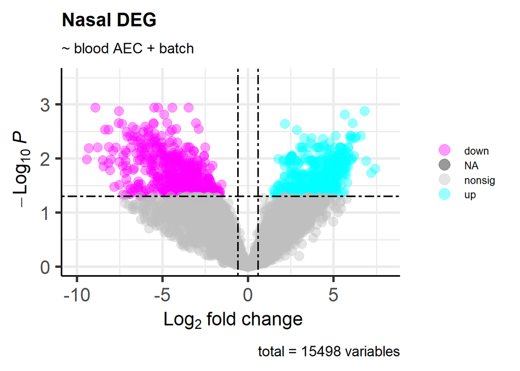

```r
library(pheatmap)
library(gridExtra)
library(grid)
nasal_data_folder<-file.path("./reports/local_only/deg_nasal-bronch~bal-blood_cell(continuous)+batch/deg_gene_list")
####################################################################
# data exploration of DEG analysis using nasal rnaseq data
# model: "Nasal DEG ~ blood AEC (>0) + Batch1234
####################################################################

res_nasal<-read.csv(file.path(nasal_data_folder,"nasal_res6.csv"),row.names = 1)
res_nasal<-res_nasal%>%mutate(deg_sig=ifelse(padj<0.05&log2FoldChange>0.585,'cyan',
                                  ifelse(padj<0.05&log2FoldChange< -0.585,'magenta',
                                         'grey')))

keyvals_n <- ifelse(res_nasal$padj<0.05&res_nasal$log2FoldChange>0.585,'cyan',
                    ifelse(res_nasal$padj<0.05&res_nasal$log2FoldChange< -0.585,'magenta',
                           'grey'))
keyvals_n[is.na(keyvals_n)] <- 'black'

names(keyvals_n)[keyvals_n == 'cyan'] <- 'up'
names(keyvals_n)[keyvals_n == 'magenta'] <- 'down'
names(keyvals_n)[keyvals_n == 'grey'] <- 'nonsig'
names(keyvals_n)[keyvals_n == 'black'] <- 'NA'

p1.3<-EnhancedVolcano(res_nasal,
                    lab = NA,
                    title='Nasal DEG',
                    subtitle = '~ blood AEC + batch',
                    x = 'log2FoldChange',
                    y = 'padj',
                    xlab = bquote(~Log[2]~ 'fold change'),
                    xlim=c(-10,8),
                    ylim=c(0,3.5),
                    pCutoff = 5e-2,
                    FCcutoff = 0.585,
                    cutoffLineType = 'twodash',
                    cutoffLineWidth = 0.8,
                    pointSize = 4.0,
                    labSize = 0.0,
                    colAlpha = 0.4,
                    selectLab = rownames(res_nasal)[which(names(keyvals_n)%in%c('up','down'))],
                    colCustom = keyvals_n,
                    legendPosition = 'right',
                    legendLabSize = 10,
                    legendIconSize = 5.0,
                    drawConnectors = TRUE,
                    widthConnectors = 0.75)
p1.3
```

## other significant: bronch ~ DEG bronch ~ bal ANC + batch12346

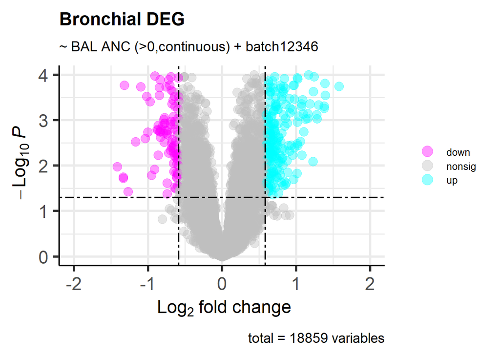

```r
library(dplyr)
library(EnhancedVolcano)
library(pheatmap)
library(gridExtra)
library(grid)
deg_ndeg_bronch_anc<-"./reports/local_only/deg_bronch~bal_cell(continuous)+batch12346/gene_list_all_results/deg_bronch_continuous_poscell+batch12346_res_all_3_~ BAL_neut_ct_log + Batch_2024-05-29_.csv"
####################################################################
# data exploration of DEG analysis using bronch rnaseq data
# model: "Bronch DEG ~ BAL ANC(>0) + Batch12346
####################################################################

res<-read.csv(file.path(deg_ndeg_bronch_anc),row.names = 1)
res<-res%>%mutate(deg_sig=ifelse(padj<0.05&log2FoldChange>0.585,'cyan',
                                  ifelse(padj<0.05&log2FoldChange< -0.585,'magenta',
                                         'grey')))

keyvals_n <- ifelse(res$padj<0.05&res$log2FoldChange>0.585,'cyan',
                    ifelse(res$padj<0.05&res$log2FoldChange< -0.585,'magenta',
                           'grey'))
keyvals_n[is.na(keyvals_n)] <- 'black'

names(keyvals_n)[keyvals_n == 'cyan'] <- 'up'
names(keyvals_n)[keyvals_n == 'magenta'] <- 'down'
names(keyvals_n)[keyvals_n == 'grey'] <- 'nonsig'
names(keyvals_n)[keyvals_n == 'black'] <- 'NA'

p<-EnhancedVolcano(res,
                    lab = NA,
                    title='Bronchial DEG',
                    subtitle = '~ BAL ANC (>0,continuous) + batch12346',
                    x = 'log2FoldChange',
                    y = 'padj',
                    xlab = bquote(~Log[2]~ 'fold change'),
                    xlim=c(-2,2),
                    ylim=c(0,4),
                    pCutoff = 5e-2,
                    FCcutoff = 0.585,
                    cutoffLineType = 'twodash',
                    cutoffLineWidth = 0.8,
                    pointSize = 4.0,
                    labSize = 0.0,
                    colAlpha = 0.4,
                    selectLab = rownames(res)[which(names(keyvals_n)%in%c('up','down'))],
                    colCustom = keyvals_n,
                    legendPosition = 'right',
                    legendLabSize = 10,
                    legendIconSize = 5.0,
                    drawConnectors = TRUE,
                    widthConnectors = 0.75)
print(p)
```

## bronch ~ BAL AEC >1000 + batch 12346

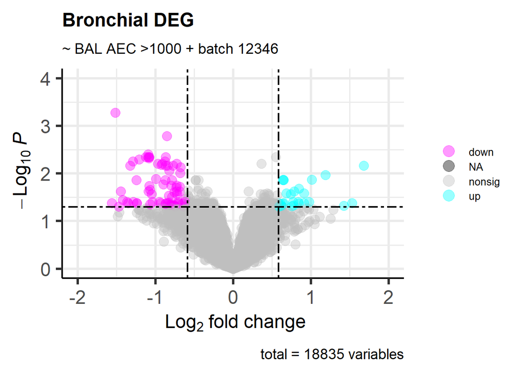

```r
library(dplyr)
library(EnhancedVolcano)
library(pheatmap)
library(gridExtra)
library(grid)
deg_ndeg_bronch_AEC_mt1<-"./reports/local_only/deg_bronch~bal_cell(dichot)+batch12346/deg_bronch_dichot_res_all_2_~ bal_AEC_more_1 + Batch_2024-08-05_.csv"
####################################################################
# data exploration of DEG analysis using bronch rnaseq data
# model: "bronch ~ BAL AEC >1000 + batch 12346
####################################################################

res<-read.csv(file.path(deg_ndeg_bronch_AEC_mt1))
res<-res%>%mutate(deg_sig=ifelse(padj<0.05&log2FoldChange>0.585,'cyan',
                                  ifelse(padj<0.05&log2FoldChange< -0.585,'magenta',
                                         'grey')))

keyvals_n <- ifelse(res$padj<0.05&res$log2FoldChange>0.585,'cyan',
                    ifelse(res$padj<0.05&res$log2FoldChange< -0.585,'magenta',
                           'grey'))
keyvals_n[is.na(keyvals_n)] <- 'black'

names(keyvals_n)[keyvals_n == 'cyan'] <- 'up'
names(keyvals_n)[keyvals_n == 'magenta'] <- 'down'
names(keyvals_n)[keyvals_n == 'grey'] <- 'nonsig'
names(keyvals_n)[keyvals_n == 'black'] <- 'NA'

p<-EnhancedVolcano(res,
                    lab = NA,
                    title='Bronchial DEG',
                    subtitle = '~ BAL AEC >1000 + batch 12346',
                    x = 'log2FoldChange',
                    y = 'padj',
                    xlab = bquote(~Log[2]~ 'fold change'),
                    xlim=c(-2,2),
                    ylim=c(0,4),
                    pCutoff = 5e-2,
                    FCcutoff = 0.585,
                    cutoffLineType = 'twodash',
                    cutoffLineWidth = 0.8,
                    pointSize = 4.0,
                    labSize = 0.0,
                    colAlpha = 0.4,
                    selectLab = rownames(res)[which(names(keyvals_n)%in%c('up','down'))],
                    colCustom = keyvals_n,
                    legendPosition = 'right',
                    legendLabSize = 10,
                    legendIconSize = 5.0,
                    drawConnectors = TRUE,
                    widthConnectors = 0.75)
print(p)
```

## bronch ~ BAL Eos% > 3% + batch 12346

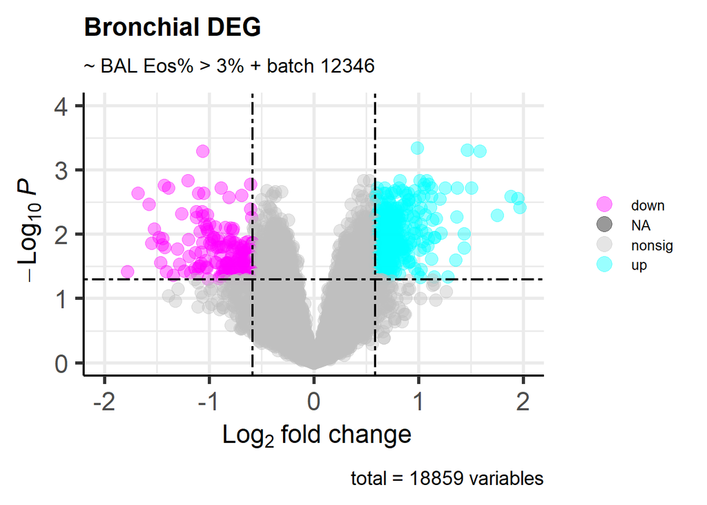

```r
library(dplyr)
library(EnhancedVolcano)
library(pheatmap)
library(gridExtra)
library(grid)
deg_ndeg_bronch_eos_p_mt3p<-"./reports/local_only/deg_bronch~bal_cell(dichot)+batch12346/deg_bronch_dichot_res_all_5_~ bal_Eos_p_more_3 + Batch_2024-05-29_.csv"
####################################################################
# data exploration of DEG analysis using bronch rnaseq data
# model: "bronch ~ BAL Eos% > 3% + batch 12346
####################################################################

res<-read.csv(file.path(deg_ndeg_bronch_eos_p_mt3p),row.names = 1)
res<-res%>%mutate(deg_sig=ifelse(padj<0.05&log2FoldChange>0.585,'cyan',
                                  ifelse(padj<0.05&log2FoldChange< -0.585,'magenta',
                                         'grey')))

keyvals_n <- ifelse(res$padj<0.05&res$log2FoldChange>0.585,'cyan',
                    ifelse(res$padj<0.05&res$log2FoldChange< -0.585,'magenta',
                           'grey'))
keyvals_n[is.na(keyvals_n)] <- 'black'

names(keyvals_n)[keyvals_n == 'cyan'] <- 'up'
names(keyvals_n)[keyvals_n == 'magenta'] <- 'down'
names(keyvals_n)[keyvals_n == 'grey'] <- 'nonsig'
names(keyvals_n)[keyvals_n == 'black'] <- 'NA'

p<-EnhancedVolcano(res,
                    lab = NA,
                    title='Bronchial DEG',
                    subtitle = '~ BAL Eos% > 3% + batch 12346',
                    x = 'log2FoldChange',
                    y = 'padj',
                    xlab = bquote(~Log[2]~ 'fold change'),
                    xlim=c(-2,2),
                    ylim=c(0,4),
                    pCutoff = 5e-2,
                    FCcutoff = 0.585,
                    cutoffLineType = 'twodash',
                    cutoffLineWidth = 0.8,
                    pointSize = 4.0,
                    labSize = 0.0,
                    colAlpha = 0.4,
                    selectLab = rownames(res)[which(names(keyvals_n)%in%c('up','down'))],
                    colCustom = keyvals_n,
                    legendPosition = 'right',
                    legendLabSize = 10,
                    legendIconSize = 5.0,
                    drawConnectors = TRUE,
                    widthConnectors = 0.75)
print(p)
```

## bronch ~ BAL Eos P continuous + batch 12346

[figure not shown]

```r
library(dplyr)
library(EnhancedVolcano)
library(pheatmap)
library(gridExtra)
library(grid)
deg_ndeg_bronch_eos_p<-"./reports/local_only/deg_bronch~bal_cell(continuous)+batch12346/gene_list_all_results/deg_bronch_continuous_allcell+batch12346_res_all_2_~ BAL_eos_p_log + Batch_2024-08-02_.csv"
####################################################################
# data exploration of DEG analysis using bronch rnaseq data
# model: "Bronch DEG ~ BAL Eos P continuous (all cells) + batch 12346
####################################################################

res<-read.csv(file.path(deg_ndeg_bronch_eos_p),row.names = 1)
res<-res%>%mutate(deg_sig=ifelse(padj<0.05&log2FoldChange>0.585,'cyan',
                                  ifelse(padj<0.05&log2FoldChange< -0.585,'magenta',
                                         'grey')))

keyvals_n <- ifelse(res$padj<0.05&res$log2FoldChange>0.585,'cyan',
                    ifelse(res$padj<0.05&res$log2FoldChange< -0.585,'magenta',
                           'grey'))
keyvals_n[is.na(keyvals_n)] <- 'black'

names(keyvals_n)[keyvals_n == 'cyan'] <- 'up'
names(keyvals_n)[keyvals_n == 'magenta'] <- 'down'
names(keyvals_n)[keyvals_n == 'grey'] <- 'nonsig'
names(keyvals_n)[keyvals_n == 'black'] <- 'NA'

p<-EnhancedVolcano(res,
                    lab = NA,
                    title='Bronchial DEG',
                    subtitle = '~ BAL ANC (>0,continuous) + batch12346',
                    x = 'log2FoldChange',
                    y = 'padj',
                    xlab = bquote(~Log[2]~ 'fold change'),
                    xlim=c(-2,2),
                    ylim=c(0,4),
                    pCutoff = 5e-2,
                    FCcutoff = 0.585,
                    cutoffLineType = 'twodash',
                    cutoffLineWidth = 0.8,
                    pointSize = 4.0,
                    labSize = 0.0,
                    colAlpha = 0.4,
                    selectLab = rownames(res)[which(names(keyvals_n)%in%c('up','down'))],
                    colCustom = keyvals_n,
                    legendPosition = 'right',
                    legendLabSize = 10,
                    legendIconSize = 5.0,
                    drawConnectors = TRUE,
                    widthConnectors = 0.75)
print(p)
```

## summarize the number of DEGs

bronchial ~ peripheral blood association is pretty weak. only bronchial ~ blood AEC > 300 had upregulated DEG related to O-glycosylation Nasal ~ BAL cell count was really weak. essentially 0 DEG.

Here, showing the # of DEG for analyses that yielded signficiant # of DEGs. criteria, abs(L2FC) > 0.585 (1.5 Fold magnitude change), padj <0.05

```r
analysis_list<-c("./reports/local_only/deg_nasal-bronch~bal-blood_cell(continuous)+batch/deg_gene_list/nasal_res6.csv",
                 "./reports/local_only/deg_bronch~bal_cell(continuous)+batch12346/gene_list_all_results/deg_bronch_continuous_poscell+batch12346_res_all_3_~ BAL_neut_ct_log + Batch_2024-05-29_.csv",
                 "./reports/local_only/deg_bronch~bal_cell(dichot)+batch12346/deg_bronch_dichot_res_all_2_~ bal_AEC_more_1 + Batch_2024-08-05_.csv",
                 "./reports/local_only/deg_bronch~bal_cell(dichot)+batch12346/deg_bronch_dichot_res_all_5_~ bal_Eos_p_more_3 + Batch_2024-05-29_.csv",
                 "./reports/local_only/deg_bronch~bal_cell(continuous)+batch12346/gene_list_all_results/deg_bronch_continuous_allcell+batch12346_res_all_2_~ BAL_eos_p_log + Batch_2024-08-02_.csv")

res_list<-lapply(analysis_list,function(list)read.csv(list,row.names = 1))
n_deg<-sapply(res_list,function(list)list%>%filter(abs(log2FoldChange)>0.585,padj<0.05)%>%summarize(n_deg=length(padj)))
names(n_deg)<-c("nasal~blood_AEC","bronch~bal_ANC","bronch~bal_AEC_mt1", "bronch~bal_eos_p_mt3","bronch~bal_eos_p_continuous_allcells")
print(n_deg)
```

```
## $`nasal~blood_AEC`
## [1] 926
##
## $`bronch~bal_ANC`
## [1] 423
##
## $`bronch~bal_AEC_mt1`
## [1] 104
##
## $`bronch~bal_eos_p_mt3`
## [1] 630
##
## $`bronch~bal_eos_p_continuous_allcells`
## [1] 33
```

# GO term

## DEG of bronch~ BAL ANC

upregulated DEG had GO that looked like this:

```r
library(stringr)
go_deg_folder<-file.path("./reports/local_only/deg_bronch~bal_cell(continuous)+batch12346/GO")
go_deg_filelist<-if(file.exists(go_deg_folder)){list.files(path=go_deg_folder)}

# Subset elements that end with ".txt"
go_files <- c("GO_down_bronch~bal-neut-ct_pos+batch12346_l2fc_mt0-58.txt", "GO_up_bronch~bal-neut-ct_pos+batch12346_l2fc_mt0-58.txt")
###
# 1. GO term for  DEG ~ BAL+batch12346
###

go_deg_terms<-lapply(file.path(go_deg_folder,go_files),read.table,sep="\t",header=TRUE)
lapply(go_deg_terms,head)
```

```
## [[1]]
##           Category       Term                                               X
## 1 GOTERM_CC_DIRECT GO:0005576                            extracellular region
## 2 GOTERM_BP_DIRECT GO:0045600 positive regulation of fat cell differentiation
## 3 GOTERM_CC_DIRECT GO:0005886                                 plasma membrane
## 4 GOTERM_BP_DIRECT GO:0050919                             negative chemotaxis
## 5 GOTERM_BP_DIRECT GO:0035725              sodium ion transmembrane transport
## 6 GOTERM_BP_DIRECT GO:0007411                                   axon guidance
##          X.      PValue
## 1 24.038462 0.000013800
## 2  4.807692 0.000129000
## 3 41.346154 0.000137000
## 4  3.846154 0.001095658
## 5  4.807692 0.002604584
## 6  5.769231 0.002768713
```

[output cut: 44 more lines]

```r
lapply(go_deg_terms,colnames)
```

```
## [[1]]
##  [1] "Category"        "Term"            "X"               "X."
##  [5] "PValue"          "Genes"           "List.Total"      "Pop.Hits"
##  [9] "Pop.Total"       "Fold.Enrichment" "Bonferroni"      "Benjamini"
## [13] "FDR"
##
## [[2]]
##  [1] "Category"        "Term"            "X"               "X."
##  [5] "PValue"          "Genes"           "List.Total"      "Pop.Hits"
##  [9] "Pop.Total"       "Fold.Enrichment" "Bonferroni"      "Benjamini"
## [13] "FDR"
```

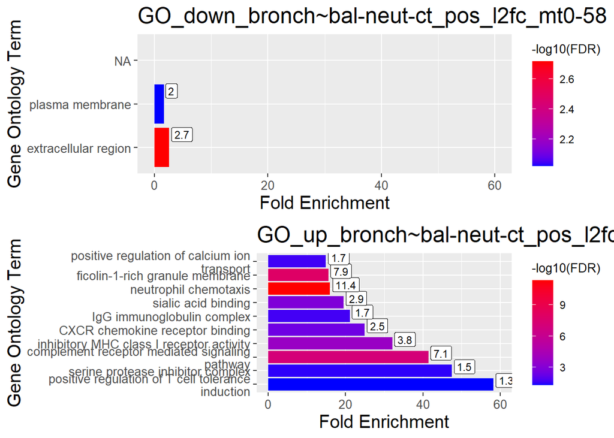

```r
# select relevant columns
go_deg_terms<-lapply(go_deg_terms,
                     function(d){
                       d[,c(2,3,6,10,13)]%>%
                         filter(FDR<0.05)%>%
                         arrange(desc(Fold.Enrichment))})

names(go_deg_terms)<-gsub("\\+batch12346", "", substr(go_files, 1, nchar(go_files) - 4))

gt<-lapply(go_deg_terms,
       function(data){
         gt<-factor(data$X,levels=data$X)
       })

for(i in 1:length(go_deg_terms)){
  go_deg_terms[[i]]$X<-gt[[i]]
}

wrapped_label<-lapply(go_deg_terms,
                      function(data){
                        go_term<-data$X
                        str_wrap(go_term, width=40)})
# Plot
library(grid)
library(gridExtra)
for(i in 1:length(go_deg_terms)){
  p<-ggplot(go_deg_terms[[i]][1:10,], aes(x = Fold.Enrichment, y = X, fill = -log10(FDR))) + # show only top 15
    geom_bar(stat = "identity") +
    geom_label(aes(label = round(-log10(FDR), 1)), fill="white",nudge_y=0.3, hjust = -0.1, size = 3, color = "black") +  # Add text labels for log10(FDR)
    scale_fill_gradient(low = "blue", high = "red") +  # Adjust color gradient as needed
    labs(x = "Fold Enrichment", y = "Gene Ontology Term", fill = "-log10(FDR)", title = names(go_deg_terms[i])) +
    theme(axis.text.x = element_text(size = 10),  # Change size of x-axis labels
        axis.text.y = element_text(size = 10),
        axis.title= element_text(size=15),
        legend.title=element_text(size=10),
        title = element_text(size=15))+  # Adjust y-axis label size for better readability
    scale_y_discrete(labels=wrapped_label[[i]])+
    xlim(0,60)

  assign(paste("a", i, sep = ""), p)
}
grobs<-list(a1,a2)
# Arrange the plots in a 2x4 grid
grid.arrange(grobs = grobs[1:2], nrow = 2)
```

LILRB genes are often expressed on granulocytes, so these might just be capturing the immune cells. (PMID: 37038910)

# Lets look at DEG bronch ~ dichotomous cell counts

complement: https://david.ncifcrf.gov/kegg.jsp?path=hsa04610$Complement%20and%20coagulation%20cascades&termId=520075482&source=kegg

```r
go_deg_folder<-file.path("./reports/local_only/deg_bronch~bal_cell(dichot)+batch12346/GO")
go_deg_filelist<-if(file.exists(go_deg_folder)){list.files(path=go_deg_folder)}

# Subset elements that end with ".txt"
txt_files <- go_deg_filelist[grep("\\.txt$", go_deg_filelist)]
print(txt_files)
```

```
##  [1] "GO-sig-bronch-deg~bal_AEC_more_1.15_down.txt"
##  [2] "GO-sig-bronch-deg~bal_AEC_more_1.15_up.txt"
##  [3] "GO-sig-bronch-deg~bal_AEC_mt_1_down.txt"
##  [4] "GO-sig-bronch-deg~bal_Eos_p_more_1_down.txt"
##  [5] "GO-sig-bronch-deg~bal_Eos_p_more_1_up.txt"
##  [6] "GO-sig-bronch-deg~bal_Eos_p_more_3_down(1).txt"
##  [7] "GO-sig-bronch-deg~bal_Eos_p_more_3_up.txt"
##  [8] "GO-sig-bronch-deg~bld_AEC_more_300_down(1).txt"
##  [9] "GO-sig-bronch-deg~bld_AEC_more_300_up.txt"
## [10] "revigo_GO-sig-bronch-deg~bal_AEC_mt_1_down.txt"
```

```r
go_deg_filelist<-txt_files
go_deg_filelist<-go_deg_filelist[c(3,6,7)]
print(go_deg_filelist)
```

```
## [1] "GO-sig-bronch-deg~bal_AEC_mt_1_down.txt"
## [2] "GO-sig-bronch-deg~bal_Eos_p_more_3_down(1).txt"
## [3] "GO-sig-bronch-deg~bal_Eos_p_more_3_up.txt"
```

```r
print(file.exists(file.path(go_deg_folder,go_deg_filelist)))
```

```
## [1] TRUE TRUE TRUE
```

```r
###
# 1. GO term for  DEG ~ BAL+batch12346
###

go_deg_terms<-lapply(file.path(go_deg_folder,go_deg_filelist),read.table,sep="\t",header=TRUE)

lapply(go_deg_terms,colnames)
```

```
## [[1]]
##  [1] "Category"        "Term"            "X"               "X."
##  [5] "PValue"          "Genes"           "List.Total"      "Pop.Hits"
##  [9] "Pop.Total"       "Fold.Enrichment" "Bonferroni"      "Benjamini"
## [13] "FDR"
##
## [[2]]
##  [1] "Category"        "Term"            "X"               "X."
##  [5] "PValue"          "Genes"           "List.Total"      "Pop.Hits"
##  [9] "Pop.Total"       "Fold.Enrichment" "Bonferroni"      "Benjamini"
## [13] "FDR"
##
## [[3]]
##  [1] "Category"        "Term"            "X"               "X."
##  [5] "PValue"          "Genes"           "List.Total"      "Pop.Hits"
##  [9] "Pop.Total"       "Fold.Enrichment" "Bonferroni"      "Benjamini"
## [13] "FDR"
```

[figure not shown]

```r
# select relevant columns
go_deg_terms<-lapply(go_deg_terms,
                     function(d){
                       d[,c(2,3,6,10,13)]%>%
                         filter(FDR<0.05)%>%
                         arrange(desc(Fold.Enrichment))})

names(go_deg_terms)<-gsub("\\+batch12346", "", substr(go_deg_filelist, 1, nchar(go_deg_filelist) - 4))

gt<-lapply(go_deg_terms,
       function(data){
         gt<-factor(data$X,levels=data$X)
       })

for(i in 1:length(go_deg_terms)){
  go_deg_terms[[i]]$X<-gt[[i]]
}

wrapped_label<-lapply(go_deg_terms,
                      function(data){
                        go_term<-data$X
                        str_wrap(go_term, width=40)})
# Plot
library(grid)
library(gridExtra)
for(i in 1:length(go_deg_terms)){
  p<-ggplot(go_deg_terms[[i]][1:10,], aes(x = Fold.Enrichment, y = X, fill = -log10(FDR))) + # show only top 15
    geom_bar(stat = "identity") +
    geom_label(aes(label = round(-log10(FDR), 1)), fill="white",nudge_y=0.3, hjust = -0.1, size = 3, color = "black") +  # Add text labels for log10(FDR)
    scale_fill_gradient(low = "blue", high = "red") +  # Adjust color gradient as needed
    labs(x = "Fold Enrichment", y = "Gene Ontology Term", fill = "-log10(FDR)", title = names(go_deg_terms[i])) +
    theme(axis.text.x = element_text(size = 10),  # Change size of x-axis labels
        axis.text.y = element_text(size = 10),
        axis.title= element_text(size=15),
        legend.title=element_text(size=10),
        title = element_text(size=15))+  # Adjust y-axis label size for better readability
    scale_y_discrete(labels=wrapped_label[[i]])
  assign(paste("a", i, sep = ""), p)
}
grobs<-list(a1,a2,a3)
# Arrange the plots in a 2x4 grid
grid.arrange(grobs = grobs[1:3], nrow = 3)
```